# co-occurrence_analysis

## Item Co-Occurrence Analysis (Market Basket Exploration)

### Objective

The goal of this analysis is to identify meaningful relationships between products based on transaction-level purchase data. Using synthetic retail data (to ensure confidentiality), this notebook explores how frequently items are purchased together and quantifies the strength of their associations.

### Approach

The analysis follows a structured workflow:

- Data preparation and transaction grouping
- Construction of item–item co-occurrence matrices
- Calculation of key association metrics:
  - **Support**
  - **Confidence**
  - **Lift**
  - **Jaccard similarity**
- Visualization of relationships through:
  - Heatmaps
  - Network graphs
  - Item-level co-occurrence breakdowns

### The Purpose

Co-occurrence analysis has direct applications in:

- Product recommendation systems
- Cross-selling strategies
- Store layout optimization
- Bundling and promotional campaigns
- Demand forecasting and inventory planning

By quantifying item relationships, businesses can move beyond intuition and design data-driven strategies that improve customer experience and increase revenue.

### Key Takeaway

This notebook demonstrates how relatively simple statistical methods, when structured correctly and paired with strong visualization, can generate actionable insights about customer purchasing behavior. While synthetic data is used here for safety, the methodology mirrors what can be applied directly to real retail or e-commerce datasets.

*All data used in this analysis is synthetic and generated for demonstration purposes.*

```python
import pandas as pd
import numpy as np
from itertools import combinations
from collections import Counter
```

```python
# --- Dataset contains 5000 rows of synthetic sales data ---
data = pd.read_csv("synthetic_sales_data__co-occurence.csv")
```

```python
data.head()
```

|  | Date | Document No | Item No | Sales Amt | Sales Qty |
| --- | --- | --- | --- | --- | --- |
| 0 | 3/27/2025 0:00 | PS-INV12000 | 010-55602 | $420.00 | 2.0 |
| 1 | 3/27/2025 0:00 | PS-INV12000 | 009-44513 | $1,875.00 | 1.0 |
| 2 | 3/27/2025 0:00 | PS-INV12000 | 011-66701 | $6,900.00 | 2.0 |
| 3 | 2/27/2025 0:00 | PS-INV12004 | 007-22343 | $4,350.00 | 3.0 |
| 4 | 2/27/2025 0:00 | PS-INV12004 | 012-77802 | $1,350.00 | 2.0 |

```python
# --- 0) Keep only what we need; normalize types ---
df = data.rename(columns=lambda c: c.strip())  # trim any stray spaces in headers
df = df[['Document No', 'Item No', 'Date']].copy()
df['Item No'] = df['Item No'].astype(str).str.strip()
df['Document No'] = df['Document No'].astype(str).str.strip()

# (optional) if Date is a string:
df['Date'] = pd.to_datetime(df['Date'], errors='coerce')
```

```python
# --- 1) One row per (document, item) so duplicates on the same ticket don't inflate pairs ---
ticket_items = df.dropna(subset=['Document No', 'Item No']).drop_duplicates(['Document No', 'Item No'])
```

```python
# Useful stats
total_docs = ticket_items['Document No'].nunique()
items_per_doc = ticket_items.groupby('Document No')['Item No'].nunique()
print(f"Total tickets: {total_docs} | avg items/ticket: {items_per_doc.mean():.2f}")
```

```
Total tickets: 1882 | avg items/ticket: 2.66
```

```python
# --- 2) Build item pairs per document and count across documents ---
pair_counter = Counter()
for items in ticket_items.groupby('Document No')['Item No'].apply(list):
    uniq = sorted(set(items))
    if len(uniq) >= 2:
        pair_counter.update(combinations(uniq, 2))  # unordered pairs A<B

pairs_df = (
    pd.DataFrame([(a,b,cnt) for (a,b), cnt in pair_counter.items()],
                 columns=['ItemA','ItemB','CoDocCount'])
    .sort_values('CoDocCount', ascending=False)
    .reset_index(drop=True)
)
```

```python
# --- 3) Per-item document frequency (for confidence/lift) ---
item_doc_counts = (
    ticket_items.groupby('Item No')['Document No'].nunique()
    .rename('DocsWithItem')
)

pairs_df = (
    pairs_df
    .merge(item_doc_counts.rename('DocsA'), left_on='ItemA', right_index=True)
    .merge(item_doc_counts.rename('DocsB'), left_on='ItemB', right_index=True)
)
```

```python
# Support, Confidence, Lift
pairs_df['Support'] = pairs_df['CoDocCount'] / total_docs
pairs_df['Conf(A→B)'] = pairs_df['CoDocCount'] / pairs_df['DocsA']
pairs_df['Conf(B→A)'] = pairs_df['CoDocCount'] / pairs_df['DocsB']
pairs_df['Lift'] = (
    pairs_df['CoDocCount'] / total_docs
) / (
    (pairs_df['DocsA']/total_docs) * (pairs_df['DocsB']/total_docs)
)
```

```python
# --- 4) Top N "frequently bought together" pairs (overall) ---
top_pairs = pairs_df.sort_values(['CoDocCount','Lift'], ascending=False).head(100)
top_pairs
```

|  | ItemA | ItemB | CoDocCount | DocsA | DocsB | Support | Conf(A→B) | Conf(B→A) | Lift |
| --- | --- | --- | --- | --- | --- | --- | --- | --- | --- |
| 0 | 012-77801 | 012-77802 | 120 | 263 | 255 | 0.063762 | 0.456274 | 0.470588 | 3.367479 |
| 1 | 007-22343 | 012-77802 | 114 | 246 | 255 | 0.060574 | 0.463415 | 0.447059 | 3.420182 |
| 2 | 007-22341 | 010-55601 | 111 | 254 | 340 | 0.058980 | 0.437008 | 0.326471 | 2.418967 |
| 3 | 009-44512 | 010-55603 | 111 | 230 | 415 | 0.058980 | 0.482609 | 0.267470 | 2.188601 |
| 4 | 010-55602 | 010-55603 | 110 | 335 | 415 | 0.058448 | 0.328358 | 0.265060 | 1.489085 |
| ... | ... | ... | ... | ... | ... | ... | ... | ... | ... |
| 92 | 008-33422 | 010-55602 | 16 | 349 | 335 | 0.008502 | 0.045845 | 0.047761 | 0.257555 |
| 83 | 008-33422 | 010-55601 | 16 | 349 | 340 | 0.008502 | 0.045845 | 0.047059 | 0.253767 |
| 108 | 006-01512 | 008-33424 | 15 | 195 | 115 | 0.007970 | 0.076923 | 0.130435 | 1.258863 |
| 99 | 008-33424 | 009-44512 | 15 | 115 | 230 | 0.007970 | 0.130435 | 0.065217 | 1.067297 |
| 106 | 007-22341 | 011-66702 | 15 | 254 | 148 | 0.007970 | 0.059055 | 0.101351 | 0.750958 |

100 rows × 9 columns

```python
def co_items(target_item, k=20, sort_by='CoDocCount'):
    sub = pairs_df[(pairs_df['ItemA']==target_item) | (pairs_df['ItemB']==target_item)].copy()
    if sub.empty:
        return sub
    # Put the "other" item in one column
    sub['Other'] = np.where(sub['ItemA']==target_item, sub['ItemB'], sub['ItemA'])
    # Pick the directional confidence that matches the target
    sub['Confidence'] = np.where(
        sub['ItemA']==target_item, sub['Conf(A→B)'], sub['Conf(B→A)']
    )
    cols = ['Other','CoDocCount','Confidence','Lift','DocsA','DocsB','ItemA','ItemB']
    return sub.sort_values([sort_by,'Lift'], ascending=False)[cols].head(k)
```

```python
co_items('012-77801', k=20)
```

|  | Other | CoDocCount | Confidence | Lift | DocsA | DocsB | ItemA | ItemB |
| --- | --- | --- | --- | --- | --- | --- | --- | --- |
| 0 | 012-77802 | 120 | 0.456274 | 3.367479 | 263 | 255 | 012-77801 | 012-77802 |
| 6 | 007-22343 | 108 | 0.410646 | 3.141612 | 246 | 263 | 007-22343 | 012-77801 |
| 28 | 006-01511 | 25 | 0.095057 | 0.553862 | 323 | 263 | 006-01511 | 012-77801 |
| 26 | 010-55603 | 25 | 0.095057 | 0.431078 | 415 | 263 | 010-55603 | 012-77801 |
| 41 | 009-44513 | 21 | 0.079848 | 0.661999 | 227 | 263 | 009-44513 | 012-77801 |
| 47 | 010-55602 | 20 | 0.076046 | 0.427218 | 335 | 263 | 010-55602 | 012-77801 |
| 49 | 010-55601 | 19 | 0.072243 | 0.399888 | 340 | 263 | 010-55601 | 012-77801 |
| 78 | 007-22342 | 17 | 0.064639 | 0.538275 | 226 | 263 | 007-22342 | 012-77801 |
| 110 | 011-66702 | 15 | 0.057034 | 0.725259 | 148 | 263 | 011-66702 | 012-77801 |
| 102 | 007-22341 | 15 | 0.057034 | 0.422592 | 254 | 263 | 007-22341 | 012-77801 |
| 112 | 008-33422 | 15 | 0.057034 | 0.307560 | 349 | 263 | 008-33422 | 012-77801 |
| 130 | 008-33424 | 14 | 0.053232 | 0.871152 | 115 | 263 | 008-33424 | 012-77801 |
| 133 | 008-33421 | 13 | 0.049430 | 0.288903 | 322 | 263 | 008-33421 | 012-77801 |
| 159 | 006-01513 | 12 | 0.045627 | 0.698136 | 123 | 263 | 006-01513 | 012-77801 |
| 152 | 006-01512 | 12 | 0.045627 | 0.440363 | 195 | 263 | 006-01512 | 012-77801 |
| 156 | 003-16146 | 12 | 0.045627 | 0.440363 | 195 | 263 | 003-16146 | 012-77801 |
| 169 | 009-44512 | 11 | 0.041825 | 0.342238 | 230 | 263 | 009-44512 | 012-77801 |
| 177 | 011-66701 | 10 | 0.038023 | 0.347373 | 206 | 263 | 011-66701 | 012-77801 |
| 187 | 008-33423 | 8 | 0.030418 | 0.245696 | 233 | 263 | 008-33423 | 012-77801 |

```python
min_docs = 5  # tweakable
popular = item_doc_counts[item_doc_counts >= min_docs].index
ticket_items_pop = ticket_items[ticket_items['Item No'].isin(popular)]
# then rebuild the pair_counter using ticket_items_pop instead of ticket_items
```

```python
top_pairs.to_csv("top_item_pairs_q1.csv", index=False)
```

```python
co_items('012-77801').to_csv('co_items_012-77801_q1.csv', index=False)
```

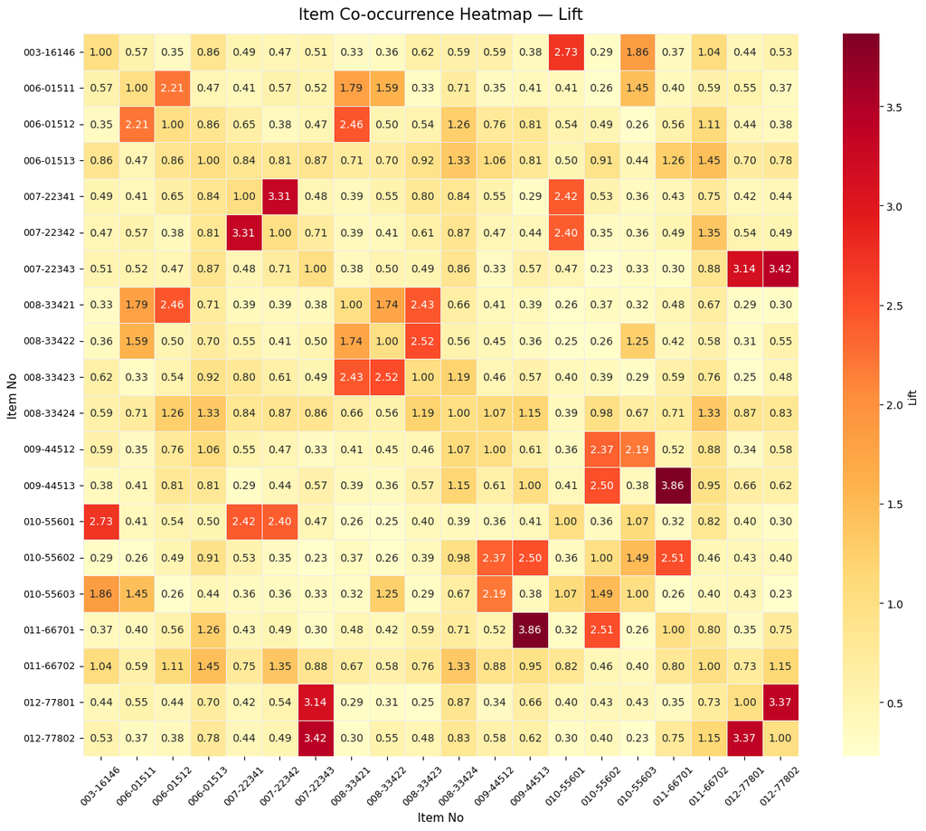

```
Saved → heatmap_lift.png
```

```python
# ─────────────────────────────────────────────
# VIZ 1 — Co-occurrence Heatmap (20×20)
# ─────────────────────────────────────────────
import matplotlib.pyplot as plt
import seaborn as sns

# Build a symmetric item×item matrix filled with Lift values
all_items = sorted(item_doc_counts.index.tolist())
heat_df = pd.DataFrame(0.0, index=all_items, columns=all_items)

for _, row in pairs_df.iterrows():
    a, b, lift = row['ItemA'], row['ItemB'], row['Lift']
    if a in heat_df.index and b in heat_df.columns:
        heat_df.loc[a, b] = lift
        heat_df.loc[b, a] = lift  # mirror

# Diagonal = 1 (an item always co-occurs with itself)
for item in all_items:
    heat_df.loc[item, item] = 1.0

fig, ax = plt.subplots(figsize=(13, 11))
sns.heatmap(
    heat_df,
    annot=True, fmt='.2f',
    cmap='YlOrRd',
    linewidths=0.5,
    linecolor='#eeeeee',
    cbar_kws={'label': 'Lift'},
    ax=ax
)
ax.set_title('Item Co-occurrence Heatmap — Lift', fontsize=15, pad=14)
ax.set_xlabel('Item No', fontsize=11)
ax.set_ylabel('Item No', fontsize=11)
ax.tick_params(axis='x', rotation=45, labelsize=9)
ax.tick_params(axis='y', rotation=0, labelsize=9)
plt.tight_layout()
plt.savefig('heatmap_lift.png', dpi=150, bbox_inches='tight')
plt.show()
print('Saved → heatmap_lift.png')
```

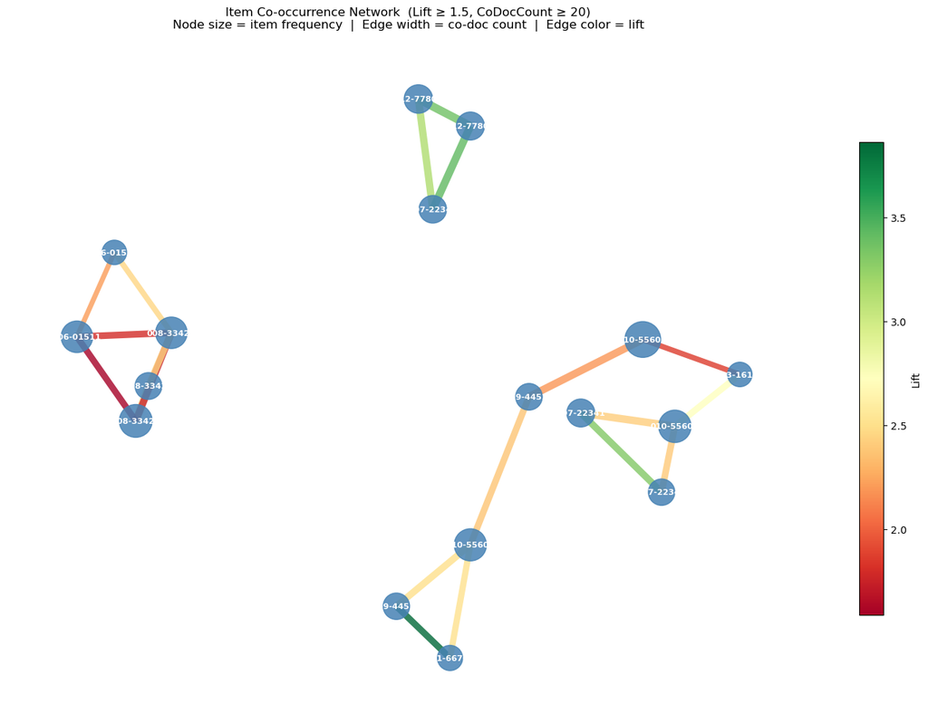

```
Nodes: 17 | Edges: 20
Saved → network_graph.png
```

```python
# ─────────────────────────────────────────────
# VIZ 2 — Network Graph (filtered by Lift)
# ─────────────────────────────────────────────
import networkx as nx
import matplotlib.pyplot as plt
import matplotlib.cm as cm
import matplotlib.colors as mcolors

# ── Tunable filters ──────────────────────────
MIN_LIFT       = 1.5   # only draw edges where lift > this
MIN_CODOCOUNT  = 20    # and co-doc count > this (removes rare pairs)
# ─────────────────────────────────────────────

filtered = pairs_df[
    (pairs_df['Lift'] >= MIN_LIFT) &
    (pairs_df['CoDocCount'] >= MIN_CODOCOUNT)
].copy()

G = nx.Graph()
for _, row in filtered.iterrows():
    G.add_edge(
        row['ItemA'], row['ItemB'],
        weight=row['CoDocCount'],
        lift=row['Lift']
    )

# Node size = how many documents contain that item
node_sizes = [
    item_doc_counts.get(n, 1) * 3
    for n in G.nodes()
]

# Edge width = CoDocCount (normalised)
max_w = max(d['weight'] for _, _, d in G.edges(data=True))
edge_widths = [d['weight'] / max_w * 8 for _, _, d in G.edges(data=True)]

# Edge color = Lift
lifts = [d['lift'] for _, _, d in G.edges(data=True)]
norm  = mcolors.Normalize(vmin=min(lifts), vmax=max(lifts))
cmap  = cm.get_cmap('RdYlGn')
edge_colors = [cmap(norm(l)) for l in lifts]

pos = nx.spring_layout(G, seed=42, k=2.5)

fig, ax = plt.subplots(figsize=(14, 10))
nx.draw_networkx_nodes(G, pos, node_size=node_sizes,
                       node_color='steelblue', alpha=0.85, ax=ax)
nx.draw_networkx_labels(G, pos, font_size=8, font_color='white',
                        font_weight='bold', ax=ax)
nx.draw_networkx_edges(G, pos, width=edge_widths,
                       edge_color=edge_colors, alpha=0.8, ax=ax)

# Colorbar for lift
sm = plt.cm.ScalarMappable(cmap=cmap, norm=norm)
sm.set_array([])
plt.colorbar(sm, ax=ax, label='Lift', shrink=0.7)

ax.set_title(
    f'Item Co-occurrence Network  (Lift ≥ {MIN_LIFT}, CoDocCount ≥ {MIN_CODOCOUNT})\n'
    f'Node size = item frequency  |  Edge width = co-doc count  |  Edge color = lift',
    fontsize=12, pad=12
)
ax.axis('off')
plt.tight_layout()
plt.savefig('network_graph.png', dpi=150, bbox_inches='tight')
plt.show()
print(f'Nodes: {G.number_of_nodes()} | Edges: {G.number_of_edges()}')
print('Saved → network_graph.png')
```

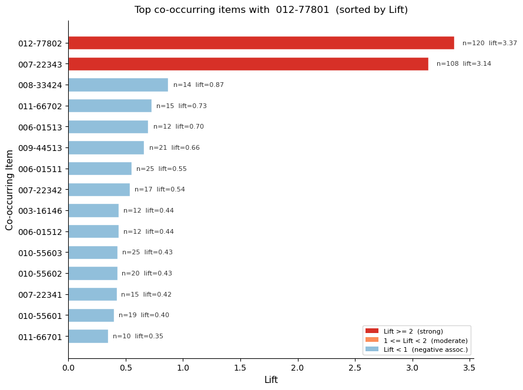

```
Saved → co_items_012_77801.png
```

```python
# ─────────────────────────────────────────────
# VIZ 3 — Per-item co-occurrence bar chart
# Drop-in replacement / companion to co_items()
# ─────────────────────────────────────────────
import matplotlib.pyplot as plt

def plot_co_items(target_item, k=15, sort_by='Lift', min_codocount=5):
    """
    Horizontal bar chart of the top-k items that co-occur with target_item.

    Parameters
    ----------
    target_item   : str   — the item you want to investigate
    k             : int   — how many co-items to show
    sort_by       : str   — 'Lift', 'CoDocCount', or 'Confidence'
    min_codocount : int   — hide pairs with fewer co-documents than this
    """
    sub = co_items(target_item, k=50, sort_by=sort_by)   # fetch wide, trim below
    if sub.empty:
        print(f'No co-occurrence data found for {target_item}')
        return

    sub = sub[sub['CoDocCount'] >= min_codocount].head(k)
    if sub.empty:
        print(f'No pairs survive the min_codocount={min_codocount} filter.')
        return

    sub = sub.sort_values(sort_by, ascending=True)   # ascending so top bar is highest

    colors = ['#d73027' if l >= 2 else '#fc8d59' if l >= 1 else '#91bfdb'
              for l in sub['Lift']]

    fig, ax = plt.subplots(figsize=(9, max(4, len(sub) * 0.45)))
    bars = ax.barh(sub['Other'], sub[sort_by], color=colors, edgecolor='white', height=0.65)

    # Annotate with CoDocCount and Lift
    for bar, (_, row) in zip(bars, sub.iterrows()):
        ax.text(
            bar.get_width() + bar.get_width() * 0.01,
            bar.get_y() + bar.get_height() / 2,
            f"  n={int(row['CoDocCount'])}  lift={row['Lift']:.2f}",
            va='center', fontsize=8, color='#333333'
        )

    ax.set_xlabel(sort_by, fontsize=11)
    ax.set_ylabel('Co-occurring Item', fontsize=11)
    ax.set_title(f'Top co-occurring items with  {target_item}  (sorted by {sort_by})',
                 fontsize=12, pad=10)

    # Legend
    from matplotlib.patches import Patch
    legend_elements = [
        Patch(facecolor='#d73027', label='Lift >= 2  (strong)'),
        Patch(facecolor='#fc8d59', label='1 <= Lift < 2  (moderate)'),
        Patch(facecolor='#91bfdb', label='Lift < 1  (negative assoc.)'),
    ]
    ax.legend(handles=legend_elements, loc='lower right', fontsize=8)
    ax.spines[['top', 'right']].set_visible(False)
    plt.tight_layout()

    fname = f'co_items_{target_item.replace("-","_")}.png'
    plt.savefig(fname, dpi=150, bbox_inches='tight')
    plt.show()
    print(f'Saved → {fname}')


# ── Example calls ─────────────────────────────
plot_co_items('012-77801', sort_by='Lift')
# plot_co_items('007-22341', sort_by='CoDocCount')
# plot_co_items('008-33421', sort_by='Confidence')
```

```python
# ─────────────────────────────────────────────────────────────
# ANALYTICS 5 — Jaccard Similarity
# More balanced than Lift when item frequencies are unequal.
# Formula: CoDocCount / (DocsA + DocsB - CoDocCount)
# Range: 0 (never together) → 1 (always together)
# ─────────────────────────────────────────────────────────────

pairs_df['Jaccard'] = (
    pairs_df['CoDocCount'] /
    (pairs_df['DocsA'] + pairs_df['DocsB'] - pairs_df['CoDocCount'])
)

# Show top pairs ranked by Jaccard — compare with Lift ranking
print('=== Top 20 pairs by Jaccard ===')
display(
    pairs_df[['ItemA','ItemB','CoDocCount','DocsA','DocsB','Jaccard','Lift']]
    .sort_values('Jaccard', ascending=False)
    .head(20)
    .reset_index(drop=True)
)

# Pairs where Lift and Jaccard rankings disagree most
# (high lift but low Jaccard = one item is very rare, inflating lift)
pairs_df['LiftRank']    = pairs_df['Lift'].rank(ascending=False)
pairs_df['JaccardRank'] = pairs_df['Jaccard'].rank(ascending=False)
pairs_df['RankDiff']    = (pairs_df['LiftRank'] - pairs_df['JaccardRank']).abs()

print('\n=== Pairs where Lift and Jaccard rankings disagree most ===')
display(
    pairs_df[['ItemA','ItemB','CoDocCount','DocsA','DocsB','Lift','Jaccard','RankDiff']]
    .sort_values('RankDiff', ascending=False)
    .head(10)
    .reset_index(drop=True)
)
```

```
=== Top 20 pairs by Jaccard ===
```

|  | ItemA | ItemB | CoDocCount | DocsA | DocsB | Jaccard | Lift |
| --- | --- | --- | --- | --- | --- | --- | --- |
| 0 | 012-77801 | 012-77802 | 120 | 263 | 255 | 0.301508 | 3.367479 |
| 1 | 007-22343 | 012-77802 | 114 | 246 | 255 | 0.294574 | 3.420182 |
| 2 | 009-44513 | 011-66701 | 96 | 227 | 206 | 0.284866 | 3.863650 |
| 3 | 007-22343 | 012-77801 | 108 | 246 | 263 | 0.269327 | 3.141612 |
| 4 | 007-22341 | 007-22342 | 101 | 254 | 226 | 0.266491 | 3.311302 |
| 5 | 008-33422 | 008-33423 | 109 | 349 | 233 | 0.230444 | 2.522695 |
| 6 | 007-22341 | 010-55601 | 111 | 254 | 340 | 0.229814 | 2.418967 |
| 7 | 009-44513 | 010-55602 | 101 | 227 | 335 | 0.219089 | 2.499599 |
| 8 | 003-16146 | 010-55601 | 96 | 195 | 340 | 0.218679 | 2.725068 |
| 9 | 008-33421 | 008-33423 | 97 | 322 | 233 | 0.211790 | 2.433210 |
| 10 | 007-22342 | 010-55601 | 98 | 226 | 340 | 0.209402 | 2.400260 |
| 11 | 009-44512 | 010-55603 | 111 | 230 | 415 | 0.207865 | 2.188601 |
| 12 | 009-44512 | 010-55602 | 97 | 230 | 335 | 0.207265 | 2.369293 |
| 13 | 010-55602 | 011-66701 | 92 | 335 | 206 | 0.204900 | 2.508970 |
| 14 | 006-01512 | 008-33421 | 82 | 195 | 322 | 0.188506 | 2.457780 |
| 15 | 008-33421 | 008-33422 | 104 | 322 | 349 | 0.183422 | 1.741693 |
| 16 | 006-01511 | 008-33421 | 99 | 323 | 322 | 0.181319 | 1.791416 |
| 17 | 010-55602 | 010-55603 | 110 | 335 | 415 | 0.171875 | 1.489085 |
| 18 | 006-01511 | 006-01512 | 74 | 323 | 195 | 0.166667 | 2.211130 |
| 19 | 006-01511 | 008-33422 | 95 | 323 | 349 | 0.164645 | 1.586044 |

```
=== Pairs where Lift and Jaccard rankings disagree most ===
```

|  | ItemA | ItemB | CoDocCount | DocsA | DocsB | Lift | Jaccard | RankDiff |
| --- | --- | --- | --- | --- | --- | --- | --- | --- |
| 0 | 003-16146 | 008-33424 | 7 | 195 | 115 | 0.587469 | 0.023102 | 84.5 |
| 1 | 008-33424 | 011-66701 | 9 | 115 | 206 | 0.714985 | 0.028846 | 72.0 |
| 2 | 008-33421 | 010-55603 | 23 | 322 | 415 | 0.323924 | 0.032213 | 64.0 |
| 3 | 006-01511 | 010-55601 | 24 | 323 | 340 | 0.411291 | 0.037559 | 63.0 |
| 4 | 010-55603 | 012-77801 | 25 | 415 | 263 | 0.431078 | 0.038285 | 62.0 |
| 5 | 008-33422 | 008-33424 | 12 | 349 | 115 | 0.562701 | 0.026549 | 62.0 |
| 6 | 010-55601 | 010-55602 | 22 | 340 | 335 | 0.363512 | 0.033691 | 60.0 |
| 7 | 006-01511 | 006-01513 | 10 | 323 | 123 | 0.473709 | 0.022936 | 54.0 |
| 8 | 006-01513 | 010-55601 | 11 | 123 | 340 | 0.495026 | 0.024336 | 52.0 |
| 9 | 008-33421 | 010-55602 | 21 | 322 | 335 | 0.366385 | 0.033019 | 51.5 |

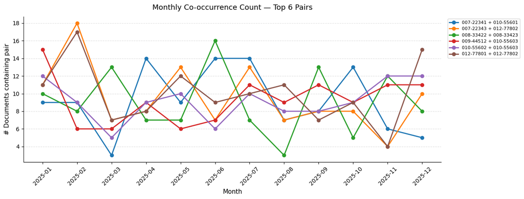

```
Saved → monthly_pair_trend.png
```

```python
# ─────────────────────────────────────────────────────────────
# ANALYTICS 6 — Monthly Trend of Top Pairs
# Are strongest bundles stable over time, or seasonal?
# ─────────────────────────────────────────────────────────────
import matplotlib.pyplot as plt
import matplotlib.ticker as mticker

# ── Tunable ───────────────────────────────────
TOP_N_PAIRS = 6   # how many pairs to track
# ──────────────────────────────────────────────

# Pick the top N pairs by overall CoDocCount
top_pair_labels = (
    pairs_df.sort_values('CoDocCount', ascending=False)
    .head(TOP_N_PAIRS)
    .apply(lambda r: f"{r['ItemA']} + {r['ItemB']}", axis=1)
    .tolist()
)
top_pair_tuples = [
    (label.split(' + ')[0], label.split(' + ')[1])
    for label in top_pair_labels
]

# Add YearMonth to the base ticket_items dataframe
ti = ticket_items.copy()
ti['YearMonth'] = ti['Date'].dt.to_period('M')

# For each month, count how many documents contain each pair
monthly_records = []
for ym, grp in ti.groupby('YearMonth'):
    doc_items_month = grp.groupby('Document No')['Item No'].apply(set)
    for (a, b), label in zip(top_pair_tuples, top_pair_labels):
        count = sum(1 for items in doc_items_month if a in items and b in items)
        monthly_records.append({'YearMonth': ym, 'Pair': label, 'CoDocCount': count})

monthly_df = pd.DataFrame(monthly_records)
monthly_pivot = monthly_df.pivot(index='YearMonth', columns='Pair', values='CoDocCount').fillna(0)
monthly_pivot.index = monthly_pivot.index.astype(str)

fig, ax = plt.subplots(figsize=(13, 5))
for col in monthly_pivot.columns:
    ax.plot(monthly_pivot.index, monthly_pivot[col], marker='o', linewidth=2, label=col)

ax.set_title(f'Monthly Co-occurrence Count — Top {TOP_N_PAIRS} Pairs', fontsize=13, pad=12)
ax.set_xlabel('Month', fontsize=11)
ax.set_ylabel('# Documents containing pair', fontsize=11)
ax.yaxis.set_major_locator(mticker.MaxNLocator(integer=True))
ax.tick_params(axis='x', rotation=45)
ax.legend(fontsize=8, bbox_to_anchor=(1.01, 1), loc='upper left')
ax.spines[['top','right']].set_visible(False)
ax.grid(axis='y', linestyle='--', alpha=0.4)
plt.tight_layout()
plt.savefig('monthly_pair_trend.png', dpi=150, bbox_inches='tight')
plt.show()
print('Saved → monthly_pair_trend.png')
```

```
=== Items flagged as frequently bought alone (AvgConfidence < 0.15) ===
```

|  | Item No | DocsWithItem | AvgConfidence |
| --- | --- | --- | --- |
| 0 | 012-77801 | 263 | 0.098459 |
| 1 | 010-55601 | 340 | 0.098607 |
| 2 | 008-33422 | 349 | 0.100739 |
| 3 | 010-55603 | 415 | 0.100951 |
| 4 | 008-33421 | 322 | 0.101177 |
| 5 | 003-16146 | 195 | 0.102294 |
| 6 | 006-01511 | 323 | 0.102330 |
| 7 | 010-55602 | 335 | 0.102907 |
| 8 | 007-22341 | 254 | 0.103191 |
| 9 | 007-22343 | 246 | 0.104407 |
| 10 | 011-66701 | 206 | 0.104497 |
| 11 | 008-33423 | 233 | 0.104811 |
| 12 | 012-77802 | 255 | 0.105263 |
| 13 | 009-44512 | 230 | 0.105950 |
| 14 | 006-01512 | 195 | 0.106073 |
| 15 | 007-22342 | 226 | 0.107126 |
| 16 | 009-44513 | 227 | 0.107350 |
| 17 | 006-01513 | 123 | 0.108686 |
| 18 | 011-66702 | 148 | 0.109531 |
| 19 | 008-33424 | 115 | 0.114416 |

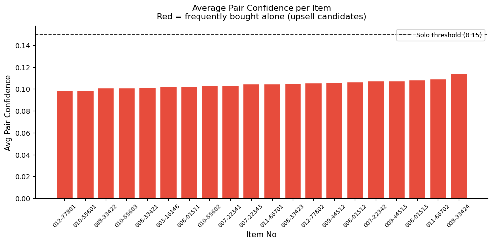

```
Saved → solo_buyer_flag.png
```

```python
# ─────────────────────────────────────────────────────────────
# ANALYTICS 7 — 'Frequently Bought Alone' Flag
# Items with low average pair-confidence are solo purchases.
# These are the best candidates for upsell / bundle promotion.
# ─────────────────────────────────────────────────────────────
import matplotlib.pyplot as plt

# ── Tunable ───────────────────────────────────
SOLO_THRESHOLD = 0.15   # avg confidence below this → flagged as solo
# ──────────────────────────────────────────────

# For each item, collect all confidence values where it appears (A→B or B→A)
conf_records = []
for _, row in pairs_df.iterrows():
    conf_records.append({'Item No': row['ItemA'], 'Confidence': row['Conf(A→B)']})
    conf_records.append({'Item No': row['ItemB'], 'Confidence': row['Conf(B→A)']})

conf_df = pd.DataFrame(conf_records)
avg_conf = (
    conf_df.groupby('Item No')['Confidence']
    .mean()
    .rename('AvgConfidence')
    .reset_index()
    .merge(item_doc_counts.reset_index().rename(columns={'Item No':'Item No','DocsWithItem':'DocsWithItem'}), on='Item No')
    .sort_values('AvgConfidence')
    .reset_index(drop=True)
)

avg_conf['SoloBuyer'] = avg_conf['AvgConfidence'] < SOLO_THRESHOLD

print(f'=== Items flagged as frequently bought alone (AvgConfidence < {SOLO_THRESHOLD}) ===')
display(avg_conf[avg_conf['SoloBuyer']][['Item No','DocsWithItem','AvgConfidence']])

# Visualise
colors = ['#e74c3c' if s else '#3498db' for s in avg_conf['SoloBuyer']]
fig, ax = plt.subplots(figsize=(10, 5))
ax.bar(avg_conf['Item No'], avg_conf['AvgConfidence'], color=colors, edgecolor='white')
ax.axhline(SOLO_THRESHOLD, color='black', linestyle='--', linewidth=1.2,
           label=f'Solo threshold ({SOLO_THRESHOLD})')
ax.set_xlabel('Item No', fontsize=11)
ax.set_ylabel('Avg Pair Confidence', fontsize=11)
ax.set_title('Average Pair Confidence per Item\n'
             'Red = frequently bought alone (upsell candidates)', fontsize=12, pad=10)
ax.tick_params(axis='x', rotation=45, labelsize=8)
ax.spines[['top','right']].set_visible(False)
ax.legend(fontsize=9)
plt.tight_layout()
plt.savefig('solo_buyer_flag.png', dpi=150, bbox_inches='tight')
plt.show()
print('Saved → solo_buyer_flag.png')
```

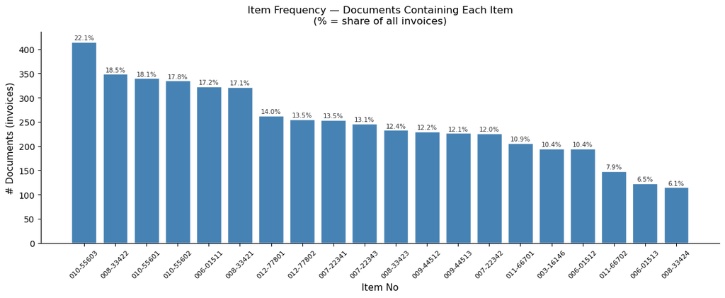

```
Saved → item_frequency.png

  Item No  DocsWithItem   PctDocs
010-55603           415 22.051010
008-33422           349 18.544102
010-55601           340 18.065887
010-55602           335 17.800213
006-01511           323 17.162593
008-33421           322 17.109458
012-77801           263 13.974495
012-77802           255 13.549416
007-22341           254 13.496281
007-22343           246 13.071201
008-33423           233 12.380446
009-44512           230 12.221041
009-44513           227 12.061637
007-22342           226 12.008502
011-66701           206 10.945802
003-16146           195 10.361318
006-01512           195 10.361318
011-66702           148  7.863974
006-01513           123  6.535600
008-33424           115  6.110521
```

```python
# ─────────────────────────────────────────────────────────────
# ANALYTICS 8 — Item Frequency Bar Chart
# Baseline context: how often each item appears across documents
# ─────────────────────────────────────────────────────────────
import matplotlib.pyplot as plt

freq = (
    item_doc_counts
    .sort_values(ascending=False)
    .reset_index()
)
freq.columns = ['Item No', 'DocsWithItem']
freq['PctDocs'] = freq['DocsWithItem'] / total_docs * 100

fig, ax = plt.subplots(figsize=(12, 5))
bars = ax.bar(
    freq['Item No'], freq['DocsWithItem'],
    color='steelblue', edgecolor='white'
)

# Annotate each bar with % of total documents
for bar, pct in zip(bars, freq['PctDocs']):
    ax.text(
        bar.get_x() + bar.get_width() / 2,
        bar.get_height() + 2,
        f'{pct:.1f}%',
        ha='center', va='bottom', fontsize=7.5, color='#333'
    )

ax.set_xlabel('Item No', fontsize=11)
ax.set_ylabel('# Documents (invoices)', fontsize=11)
ax.set_title('Item Frequency — Documents Containing Each Item\n'
             '(% = share of all invoices)', fontsize=12, pad=10)
ax.tick_params(axis='x', rotation=45, labelsize=8)
ax.spines[['top','right']].set_visible(False)
plt.tight_layout()
plt.savefig('item_frequency.png', dpi=150, bbox_inches='tight')
plt.show()
print('Saved → item_frequency.png')
print()
print(freq.to_string(index=False))
```